# Project One: Multiple Regression, Qualitative Variables Interactions, Quadratic Regression

For Project One, you have been asked to create different regression models analyzing a housing data set. Before beginning work on the project, be sure to read through the Project One Guidelines and Rubric to understand what you need to do and how you will be graded on this assignment. Be sure to carefully review the Project One Summary Report template, which contains all of the questions that you will need to answer about the regression analyses you are performing.

For this project, you will be writing all the scripts yourself. You may reference the textbook and your previous work on the problem sets to help you write the scripts.

### Scenario

You are a data analyst working for a real estate company. You have access to a large set of historical data that you can use to analyze relationships between different attributes of a house (such as square footage or the number of bathrooms) and the house’s selling price. You have been asked to create different regression models to predict sale prices for houses based on critical variable factors. These regression models will help your company set better prices when listing a home for a client. Setting better prices will ensure that listings can be sold within a reasonable amount of time.

There are several variables in this data set, but you will be working with the following important variables:

| Variable | What does it represent? |
| --- | --- |
| price | Sale price of the home |
| bedrooms | Number of bedrooms |
| bathrooms | Number of bathrooms |
| sqft_living | Size of the living area in sqft |
| sqft_above | Size of the upper level in sqft |
| sqft_lot | Size of the lot in sqft |
| age | Age of the home |
| grade | Measure of craftsmanship and the quality of materials used to build the home |
| appliance_age | Average age of all appliances in the home |
| crime | Crime rate per 100,000 people |
| backyard | Home has a backyard (backyard=1) or not (backyard=0) |
| view | Home backs out to a lake (view=2), backs out to trees (view=1), or backs out to a road (view=0) |

# Prepare Your Data Set

In the following code block, you have been given the R code to prepare your data set.

Click the **Run** button on the toolbar to run this code.

```r
housing <- read.csv(file="housing.csv", header=TRUE, sep=",")

# converting appropriate variables to factors
housing <- within(housing, {
   view <- factor(view)
   backyard <- factor(backyard)
})

# number of columns
ncol(housing)

# number of rows
nrow(housing)
```

22

2692

# Model #1 - First Order Regression Model with Quantitative and Qualitative Variables

You have been asked to create a first order regression model for *price* as the response variable, and *sqft_living*, *grade*, *bathrooms*, and *view* as predictor variables. Before writing any code, review Section 3 of the Summary Report template to see the questions you will be answering about your first order multiple regression model.

Run your scripts to get the outputs of your regression analysis. Then use the outputs to answer the questions in your summary report.

**Note: Use the + (plus) button to add new code blocks, if needed.**

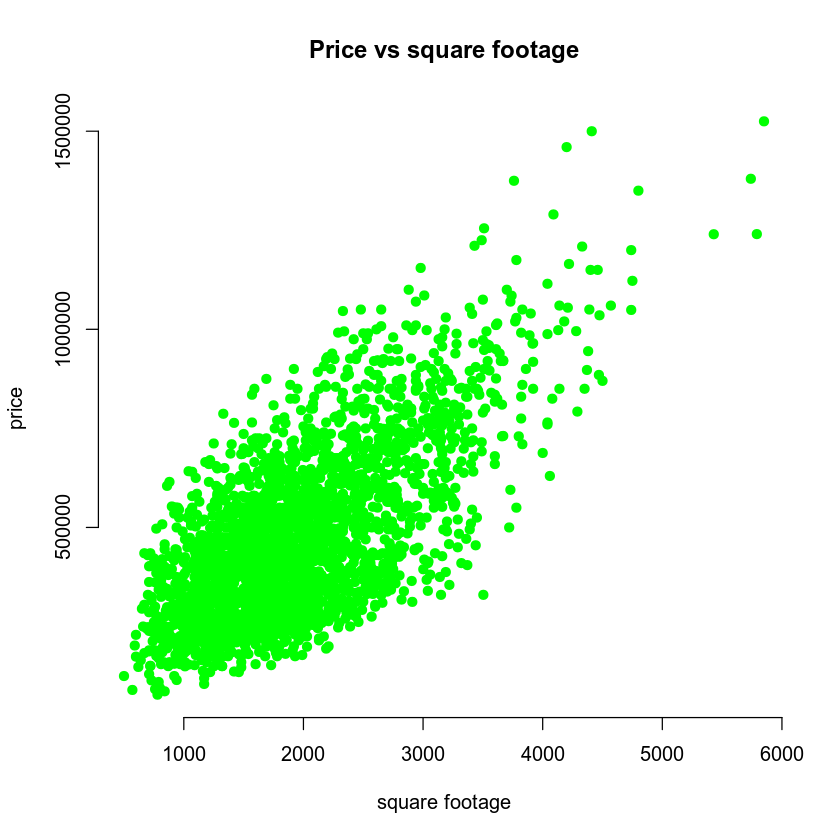

```r
plot(housing$sqft_living, housing$price,
     main = "Price vs square footage",
     xlab = "square footage", ylab = "price",
     col="green",
     pch = 19, frame = FALSE)
```

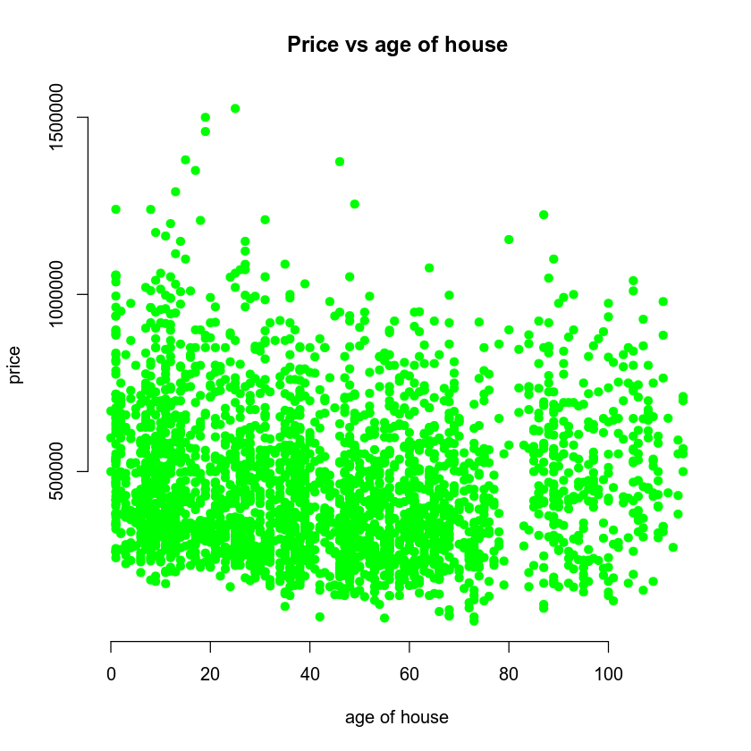

```r
plot(housing$age, housing$price,
     main = "Price vs age of house",
     xlab = "age of house", ylab = "price",
     col="green",
     pch = 19, frame = FALSE)
```

```r
corrs <- c("price","sqft_living", "age")
m1subset <- housing[corrs]

corr_matrix <- cor(m1subset, method = "pearson")
round(corr_matrix, 4)
```

A matrix: 3 × 3 of type dbl

|  | price | sqft_living | age |
| --- | --- | --- | --- |
| price | 1.0000 | 0.6895 | -0.0746 |
| sqft_living | 0.6895 | 1.0000 | -0.3547 |
| age | -0.0746 | -0.3547 | 1.0000 |

```r
regsubset <- c("price", "sqft_living", "grade", "bathrooms", "view")
m1_subset <- housing[regsubset]

model1 <- lm(price ~ sqft_living + grade + bathrooms + view, data=m1_subset)
summary(model1)
```

```
Call:
lm(formula = price ~ sqft_living + grade + bathrooms + view,
    data = m1_subset)

Residuals:
    Min      1Q  Median      3Q     Max
-378025  -91106   -8356   83217  383148

Coefficients:
              Estimate Std. Error t value Pr(>|t|)
(Intercept) -2.982e+05  2.118e+04 -14.083  < 2e-16 ***
sqft_living  9.384e+01  5.524e+00  16.986  < 2e-16 ***
grade        8.058e+04  3.574e+03  22.545  < 2e-16 ***
bathrooms   -2.182e+04  5.148e+03  -4.238 2.33e-05 ***
view1        1.657e+05  1.000e+04  16.559  < 2e-16 ***
view2        2.287e+05  1.134e+04  20.170  < 2e-16 ***
---
Signif. codes:  0 '***' 0.001 '**' 0.01 '*' 0.05 '.' 0.1 ' ' 1

Residual standard error: 125800 on 2686 degrees of freedom
Multiple R-squared:  0.6475,	Adjusted R-squared:  0.6469
F-statistic: 986.9 on 5 and 2686 DF,  p-value: < 2.2e-16
```

**Fitted and residual values & QQ for Model 1**

```r
fitted_values <- fitted.values(model1)
residuals <- residuals(model1)
print('fitted values')
print(fitted_values)
```

[output not shown]

[output cut: 620 more lines]

[output not shown]

```r
print('residuals')
print(residuals)
```

[output not shown]

[output cut: 1024 more lines]

[output not shown]

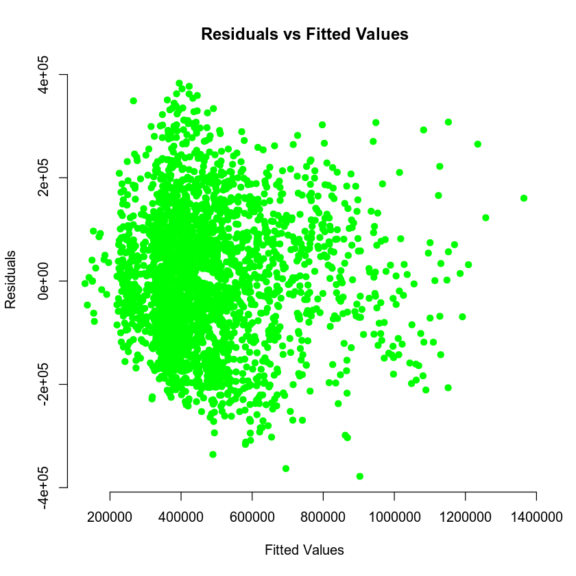

```r
plot(fitted_values, residuals,
     main = "Residuals vs Fitted Values",
     xlab = "Fitted Values", ylab = "Residuals",
     col="green",
     pch = 19, frame = FALSE)
```

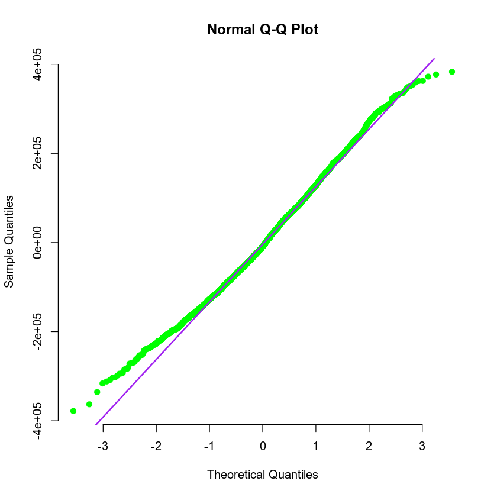

```r
qqnorm(residuals, pch = 19, col="green", frame = FALSE)
qqline(residuals, col = "purple", lwd = 2)
```

**PREDICTION AND CONFIDENCE INTERVALS**

```r
scenario1 <- data.frame(sqft_living=2150, grade=7, bathrooms=3, view='2')

print("prediction interval")
prediction_pred_int <- predict(model1, scenario1, interval="predict", level=0.90)
round(prediction_pred_int, 4)

print("confidence interval")
prediction_conf_int <- predict(model1, scenario1, interval="confidence", level=0.90)
round(prediction_conf_int, 4)
```

```
[1] "prediction interval"
```

A matrix: 1 × 3 of type dbl

| fit | lwr | upr |
| --- | --- | --- |
| 630785.7 | 422684.5 | 838887 |

```
[1] "confidence interval"
```

A matrix: 1 × 3 of type dbl

| fit | lwr | upr |
| --- | --- | --- |
| 630785.7 | 610013.7 | 651557.7 |

```r
scenario2 <- data.frame(sqft_living=2150, grade=7, bathrooms=3, view='0')

# Prediction 2 for living area of 2,150sq ft, grade 7, 3 bathrooms and road view
print("prediction interval")
prediction_pred_int <- predict(model1, scenario2, interval="predict", level=0.90)
round(prediction_pred_int, 4)

print("confidence interval")
prediction_conf_int <- predict(model1, scenario2, interval="confidence", level=0.90)
round(prediction_conf_int, 4)
```

```
[1] "prediction interval"
```

A matrix: 1 × 3 of type dbl

| fit | lwr | upr |
| --- | --- | --- |
| 402121.9 | 194826 | 609417.9 |

```
[1] "confidence interval"
```

A matrix: 1 × 3 of type dbl

| fit | lwr | upr |
| --- | --- | --- |
| 402121.9 | 392274.8 | 411969.1 |

# Model #2 - Complete Second Order Regression Model with Quantitative Variables

You have been asked to create a complete second order regression model for *price* as the response variable, and *appliance_age* and *crime* as predictor variables. Before writing any code, review Section 4 of the Summary Report template to see the questions you will be answering about your complete second order multiple regression model.

Run your scripts to get the outputs of your regression analysis. Then use the outputs to answer the questions in your summary report.

**Note: Use the + (plus) button to add new code blocks, if needed.**

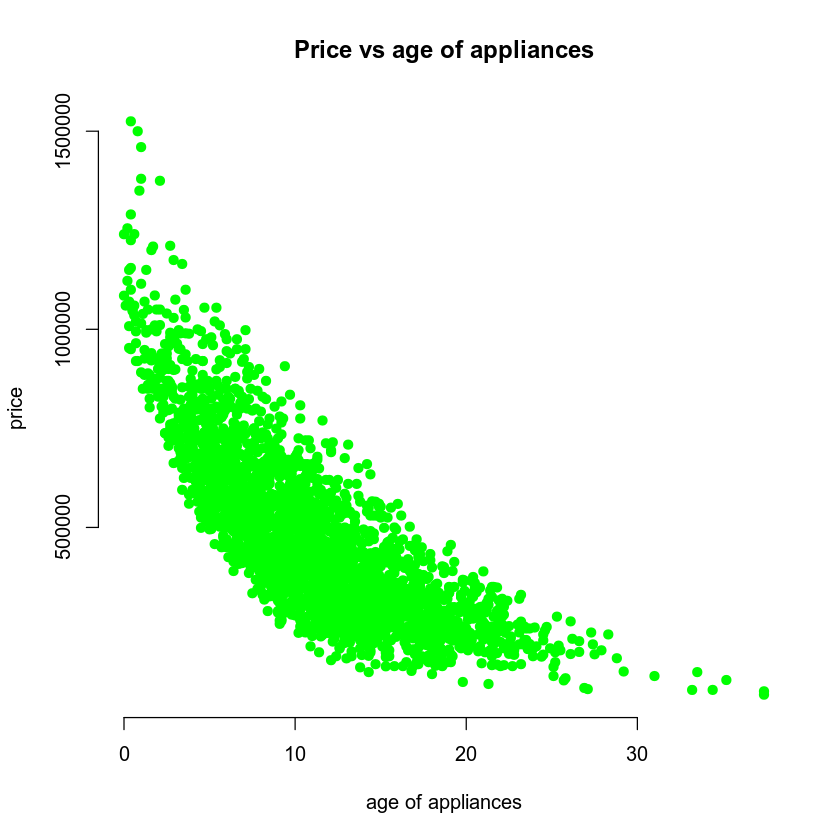

```r
plot(housing$appliance_age, housing$price,
     main = "Price vs age of appliances",
     xlab = "age of appliances", ylab = "price",
     col="green",
     pch = 19, frame = FALSE)
```

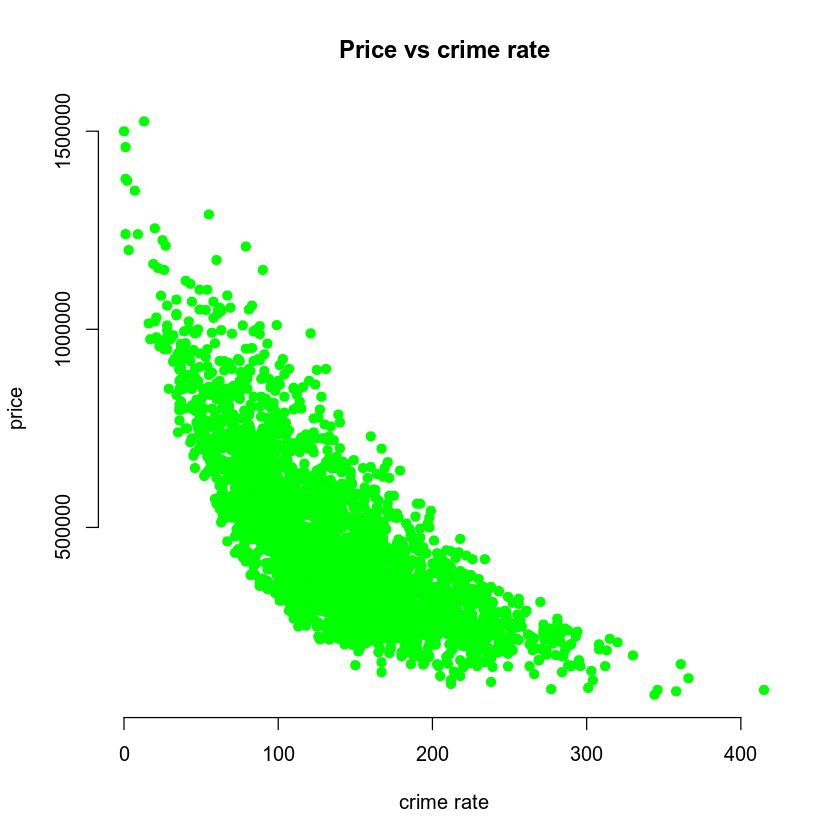

```r
plot(housing$crime, housing$price,
     main = "Price vs crime rate",
     xlab = "crime rate", ylab = "price",
     col="green",
     pch = 19, frame = FALSE)
```

```r
regsubset2 <- c("price", "appliance_age", "crime")
q2subset <- housing[regsubset2]

model2 <- lm(price ~ appliance_age + crime + appliance_age:crime + I(appliance_age^2) + I(crime^2), data=q2subset)
summary(model2)
```

```
Call:
lm(formula = price ~ appliance_age + crime + appliance_age:crime +
    I(appliance_age^2) + I(crime^2), data = q2subset)

Residuals:
    Min      1Q  Median      3Q     Max
-340502  -61196   -6241   57054  427449

Coefficients:
                      Estimate Std. Error t value Pr(>|t|)
(Intercept)          1.161e+06  9.116e+03 127.376   <2e-16 ***
appliance_age       -4.256e+04  1.375e+03 -30.951   <2e-16 ***
crime               -3.678e+03  1.481e+02 -24.827   <2e-16 ***
I(appliance_age^2)   8.330e+02  7.933e+01  10.501   <2e-16 ***
I(crime^2)           6.380e+00  7.265e-01   8.782   <2e-16 ***
appliance_age:crime  1.390e+01  1.298e+01   1.072    0.284
---
Signif. codes:  0 '***' 0.001 '**' 0.01 '*' 0.05 '.' 0.1 ' ' 1

Residual standard error: 92690 on 2686 degrees of freedom
Multiple R-squared:  0.8088,	Adjusted R-squared:  0.8084
F-statistic:  2272 on 5 and 2686 DF,  p-value: < 2.2e-16
```

**RESIDUAL AND FITTED VALUES**

```r
fitted_values <- fitted.values(model2)
print(fitted_values)
```

[output not shown]

[output cut: 619 more lines]

[output not shown]

```r
residuals <- residuals(model2)
print(residuals)
```

[output not shown]

[output cut: 1023 more lines]

[output not shown]

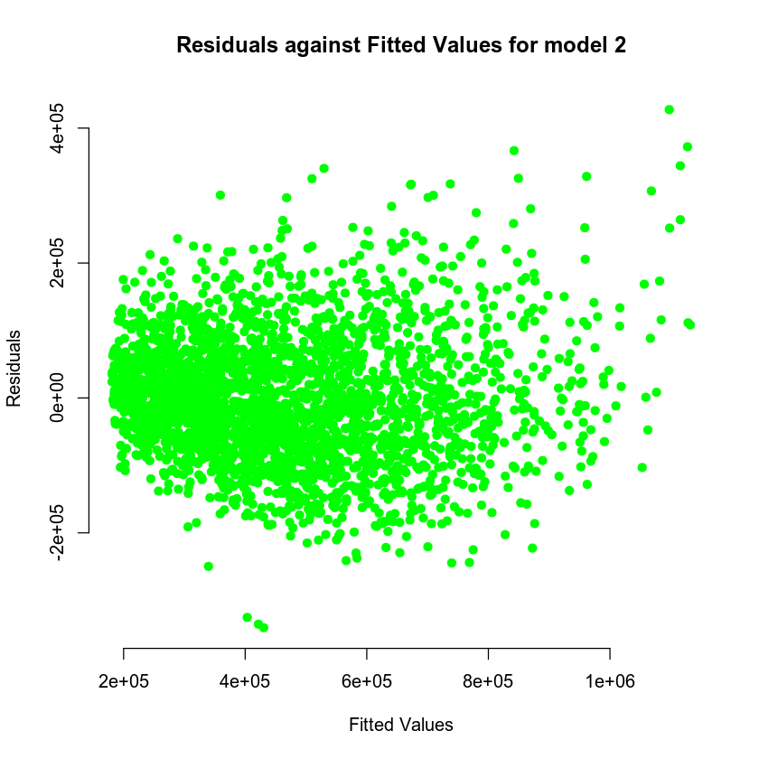

```r
plot(fitted_values, residuals,
     main = "Residuals against Fitted Values for model 2",
     xlab = "Fitted Values", ylab = "Residuals",
     col="green",
     pch = 19, frame = FALSE)
```

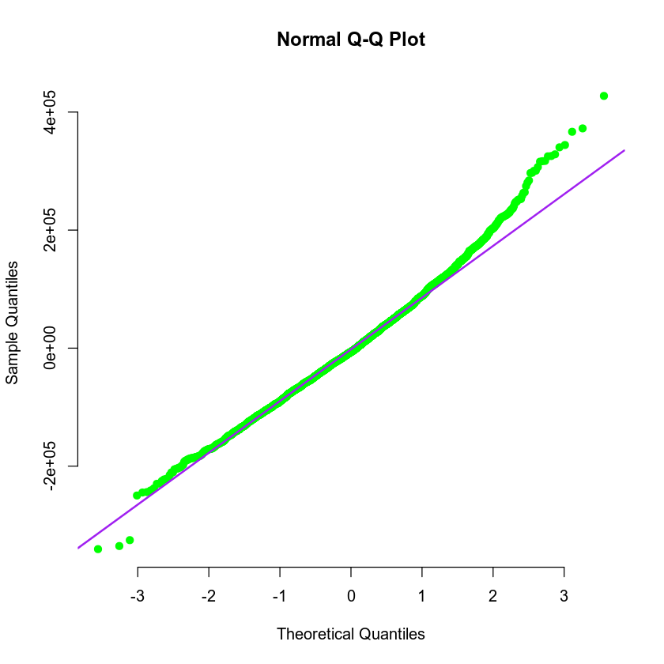

```r
qqnorm(residuals, pch = 19, col="green", frame = FALSE)
qqline(residuals, col = "purple", lwd = 2)
```

**Scenario with 1y/o appliances and crime rate of 81.02**

```r
scenario1 <- data.frame(appliance_age=1, crime=81.02)

print("prediction interval")
prediction_pred_int <- predict(model2, scenario1, interval="predict", level=0.90)
round(prediction_pred_int,4)

print("confidence interval")
prediction_conf_int <- predict(model2, scenario1, interval="confidence", level=0.90)
round(prediction_conf_int,4)
```

```
[1] "prediction interval"
```

A matrix: 1 × 3 of type dbl

| fit | lwr | upr |
| --- | --- | --- |
| 864423.4 | 711566.6 | 1017280 |

```
[1] "confidence interval"
```

A matrix: 1 × 3 of type dbl

| fit | lwr | upr |
| --- | --- | --- |
| 864423.4 | 854109.1 | 874737.7 |

```r
scenario2 <- data.frame(appliance_age=15, crime=200.50)

print("prediction interval")
prediction_pred_int <- predict(model2, scenario2, interval="predict", level=0.90)
round(prediction_pred_int,4)

print("confidence interval")
prediction_conf_int <- predict(model2, scenario2, interval="confidence", level=0.90)
round(prediction_conf_int,4)
```

```
[1] "prediction interval"
```

A matrix: 1 × 3 of type dbl

| fit | lwr | upr |
| --- | --- | --- |
| 271051.6 | 118454.4 | 423648.8 |

```
[1] "confidence interval"
```

A matrix: 1 × 3 of type dbl

| fit | lwr | upr |
| --- | --- | --- |
| 271051.6 | 265846 | 276257.2 |

# Nested Models F-Test

You have been asked to create a reduced model and compare it with the complete second order model (Model #2 above). Before writing any code, review Section 5 of the Summary Report template to see the questions you will need to answer.

Run your scripts to get the outputs of your regression analysis. Then use the outputs to answer the questions in your summary report.

**Note: Use the + (plus) button to add new code blocks, if needed.**

**REDUCED MODEL AND COMPARISON**

```r
reduced <- c("price", "appliance_age", "crime")
model2_subset <- housing[reduced]

model2_reduced <- lm(price ~ appliance_age + crime + appliance_age:crime, data=model2_subset)
summary(model2_reduced)
```

```
Call:
lm(formula = price ~ appliance_age + crime + appliance_age:crime,
    data = model2_subset)

Residuals:
    Min      1Q  Median      3Q     Max
-336702  -63621   -4269   58742  439941

Coefficients:
                      Estimate Std. Error t value Pr(>|t|)
(Intercept)          1.145e+06  8.792e+03  130.27   <2e-16 ***
appliance_age       -4.159e+04  8.377e+02  -49.65   <2e-16 ***
crime               -3.418e+03  7.097e+01  -48.17   <2e-16 ***
appliance_age:crime  1.510e+02  4.775e+00   31.63   <2e-16 ***
---
Signif. codes:  0 '***' 0.001 '**' 0.01 '*' 0.05 '.' 0.1 ' ' 1

Residual standard error: 94880 on 2688 degrees of freedom
Multiple R-squared:  0.7995,	Adjusted R-squared:  0.7993
F-statistic:  3573 on 3 and 2688 DF,  p-value: < 2.2e-16
```

**NESTED MODEL F-TEST**

```r
anova(model2, model2_reduced)
```

A anova: 2 × 6

| Res.Df <dbl> | RSS <dbl> | Df <dbl> | Sum of Sq <dbl> | F <dbl> | Pr(>F) <dbl> |
| --- | --- | --- | --- | --- | --- |
| 2686 | 2.307487e+13 | NA | NA | NA | NA |
| 2688 | 2.419614e+13 | -2 | -1.121271e+12 | 65.26001 | 2.113594e-28 |

## End of Project One Jupyter Notebook

The HTML output can be downloaded by clicking **File**, then **Download as**, then **HTML**. Be sure to answer all of the questions in the Summary Report template for Project One, and to include your completed Jupyter Notebook scripts as part of your submission.